# DATA429/599: Foundations of Random Sets and Estimators

### Learning Objectives

This Rmd is mean to accompany a hands-on sampling activity to help students practice:

- Drawing random subsets from a finite population
- Estimate means and totals
- Compute sampling distributions
- Calculate expected value, variance, bias, and mean squared error

### I. Framework for Probability Sampling

Suppose we have a finite **population**, or **universe**, of size $N$ and we would like to select of sample of size $n$.

#### A. Subsets/Samples

The number of subsets of size $n$ from the population of size $N$ can be enumerated by
$${N\choose
n}=\frac{N!}{n!(N-n!)}$$

```r
### HOW MANY COMBINATIONS?
### POP SIZE 4
### SAMP SIZE 2
allCombos<-combn(1:4, 2)
allCombos
```

```
##      [,1] [,2] [,3] [,4] [,5] [,6]
## [1,]    1    1    1    2    2    3
## [2,]    2    3    4    3    4    4
```

```r
## DIM
dim(allCombos)
```

```
## [1] 2 6
```

#### B. Probability Models

Each possible sample from the population has a known probability of selection.

Recall: Probability Axioms - Non-negativity: Probability for each subset is greater than or equal to 0 - Normalization: The sum of the probabilities for each sample is equal to 1

Consider the two probability models

```r
# Probabilities correspond to the following observing the following sets (in order)
## S_1 = {1,2}, S_2 = {1,3}, S_3 = {1,4},
## S_4 = {2,3}, S_5 = {2,4}, S_6 = {3,4}

### MODEL 1
probs1<-rep(1/6, 6)
probs1
```

```
## [1] 0.1666667 0.1666667 0.1666667 0.1666667 0.1666667 0.1666667
```

```r
### MODEL 2
probs2<-c(1/3, 1/6, 0, 0, 0, 1/2)
probs2
```

```
## [1] 0.3333333 0.1666667 0.0000000 0.0000000 0.0000000 0.5000000
```

We can randomly select a sample using the first sampling plan.

```r
### A SINGLE SELECTION FROM DISTR 1
obsProb1<-sample(1:6, size=1, prob=probs1)

### WHICH SUBSET DID WE CHOOSE?
allCombos[,obsProb1]
```

```
## [1] 2 4
```

### III. Sampling Distributions

Let’s turn our sets above into a data frame so that we can play with it some more!

```r
## MAKE A DATA FRAME
sets4C2<-data.frame(set=1:6,
                    firstObs = allCombos[1,],
                    secondObs = allCombos[2,],
                    prob=rep(1/6, 6))

sets4C2
```

```
##   set firstObs secondObs      prob
## 1   1        1         2 0.1666667
## 2   2        1         3 0.1666667
## 3   3        1         4 0.1666667
## 4   4        2         3 0.1666667
## 5   5        2         4 0.1666667
## 6   6        3         4 0.1666667
```

The sample mean $\bar{y}$ is one of the most common statistics.

```r
### WE'RE GOING TO NEED TIDYVERSE FOR THIS
library(tidyverse)

### SAMPLE MEAN
sets4C2<-sets4C2%>%
  mutate(y_bar=(firstObs+secondObs)/2)

sets4C2
```

```
##   set firstObs secondObs      prob y_bar
## 1   1        1         2 0.1666667   1.5
## 2   2        1         3 0.1666667   2.0
## 3   3        1         4 0.1666667   2.5
## 4   4        2         3 0.1666667   2.5
## 5   5        2         4 0.1666667   3.0
## 6   6        3         4 0.1666667   3.5
```

Suppose that we really want to calculate the total and not the mean. We can estimate the total using the estimator
$$\hat{t}=N\bar{y}$$

```r
### ESTIMATE THE TOTAL
sets4C2<-sets4C2%>%
  mutate(t_hat=y_bar*4)

sets4C2
```

```
##   set firstObs secondObs      prob y_bar t_hat
## 1   1        1         2 0.1666667   1.5     6
## 2   2        1         3 0.1666667   2.0     8
## 3   3        1         4 0.1666667   2.5    10
## 4   4        2         3 0.1666667   2.5    10
## 5   5        2         4 0.1666667   3.0    12
## 6   6        3         4 0.1666667   3.5    14
```

To sum the probabilities of the unique values to yield the sample distribution of $\hat{t}$

```r
sampD_tHat<-sets4C2%>%
  group_by(t_hat)%>%
  summarise(tHatProb=sum(prob))

sampD_tHat
```

```
## # A tibble: 5 × 2
##   t_hat tHatProb
##   <dbl>    <dbl>
## 1     6    0.167
## 2     8    0.167
## 3    10    0.333
## 4    12    0.167
## 5    14    0.167
```

Let’s visualize that!

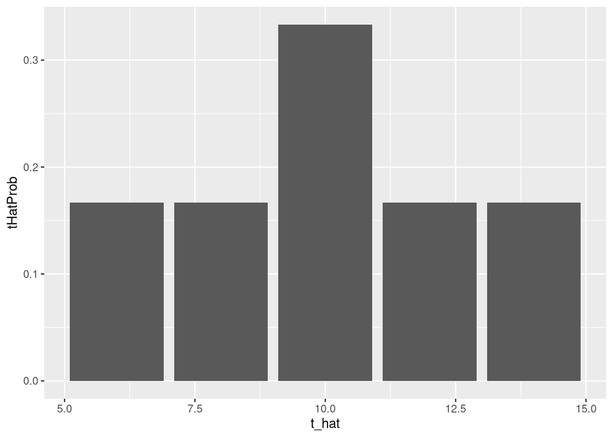

```r
ggplot(data=sampD_tHat, aes(x=t_hat, y=tHatProb))+
  geom_col()
```

#### A. Expected Value

First, let’s motivate this with the long-run average by simulating the estimated total many times.

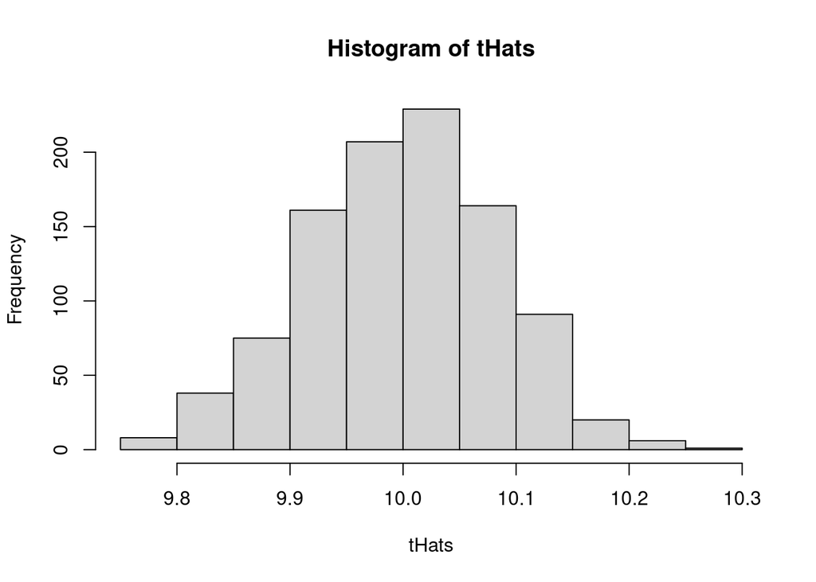

```r
nsim <-1000
tHats<-c()
for(i in 1:1000){
  ## Pick a subset randomly
  simProb1<-sample(1:6, size=1000, prob=probs1, replace = TRUE)
  ## Which subset is that?
  simObs1<-as.numeric(allCombos[,simProb1])
  ## Calculate the estimator
  this_tHat<-mean(simObs1)*4
  ## Store for later
  tHats<-c(tHats, this_tHat)
}

hist(tHats)
```

#### Think about it!

What do you think the expected value would be?

#### Theory Based Definition

The **expected value** is the mean of the sampling distribution of a statistic. This can be thought of as a weighted average, using the probability.

$$E[\hat{t}]=\sum_k k
Pr(\hat{t}=k)$$

```r
### EXPECTED VALUE
### STEP 1: CALCULATE THE SUMMANDS
expectedVal<-sampD_tHat%>%
  mutate(summands=t_hat*tHatProb)

expectedVal
```

```
## # A tibble: 5 × 3
##   t_hat tHatProb summands
##   <dbl>    <dbl>    <dbl>
## 1     6    0.167     1
## 2     8    0.167     1.33
## 3    10    0.333     3.33
## 4    12    0.167     2
## 5    14    0.167     2.33
```

```r
### STEP 2: ADD THEM TOGETHER
sum(expectedVal$summands)
```

```
## [1] 10
```

How far off are we?

#### B. Bias

This bias is the mathematical difference between the expected value of the estimator and the true value.

$$Bias[\hat{t}]=E[\hat{t}]-t$$

In reality, we don’t usually know the true value.

In this case, we know the true value.

```r
### TRUE TOTAL
sum(1:4)
```

```
## [1] 10
```

Since the difference is zero, we would say that this estimator is **unbiased**.

#### C. Variance

Variance describes how spread out the estimators are.

$$V[\hat{t}]=E[(\hat{t}-E[\hat{t}])^2]=\sum_k
P(\hat{t}=k)(k-E[\hat{t}])^2$$

```r
### VARIANCE
### STEP 1: Differences
var_tHat<-expectedVal%>%
  mutate(v_diffs=t_hat-10)

var_tHat
```

```
## # A tibble: 5 × 4
##   t_hat tHatProb summands v_diffs
##   <dbl>    <dbl>    <dbl>   <dbl>
## 1     6    0.167     1         -4
## 2     8    0.167     1.33      -2
## 3    10    0.333     3.33       0
## 4    12    0.167     2          2
## 5    14    0.167     2.33       4
```

```r
### STEP 2: SQUARE DIFFERENCES
var_tHat<-expectedVal%>%
  mutate(v_diffs=t_hat-10)%>%
  mutate(v_diffSqr=v_diffs^2)

var_tHat
```

```
## # A tibble: 5 × 5
##   t_hat tHatProb summands v_diffs v_diffSqr
##   <dbl>    <dbl>    <dbl>   <dbl>     <dbl>
## 1     6    0.167     1         -4        16
## 2     8    0.167     1.33      -2         4
## 3    10    0.333     3.33       0         0
## 4    12    0.167     2          2         4
## 5    14    0.167     2.33       4        16
```

```r
### STEP 3: WEIGHT
var_tHat<-expectedVal%>%
  mutate(v_diffs=t_hat-10)%>%
  mutate(v_diffSqr=v_diffs^2)%>%
  mutate(v_summands=v_diffSqr*tHatProb)

var_tHat
```

```
## # A tibble: 5 × 6
##   t_hat tHatProb summands v_diffs v_diffSqr v_summands
##   <dbl>    <dbl>    <dbl>   <dbl>     <dbl>      <dbl>
## 1     6    0.167     1         -4        16      2.67
## 2     8    0.167     1.33      -2         4      0.667
## 3    10    0.333     3.33       0         0      0
## 4    12    0.167     2          2         4      0.667
## 5    14    0.167     2.33       4        16      2.67
```

```r
### STEP 4: ADD
sum(var_tHat$v_summands)
```

```
## [1] 6.666667
```

#### D. Mean Squared Error

$$MSE[\hat{t}]=V[\hat{t}]+[Bias({\hat{t}})]^2$$

In this case the MSE is

```r
### MSE = VAR + BIAS^2
sum(var_tHat$v_summands)+0^2
```

```
## [1] 6.666667
```

### IV. Inclusion Probability

To motivate this, let’s simulate several draws to see the distribution of how often different IDs are chosen.

```r
### SIMULATE REPEATED DRAWS FROM THE POPULATION
### USE SAMPLING PLAN 1
simProb1<-sample(1:6, size=1000, prob=probs1, replace = TRUE)

### WHICH OBS?
simObs1<-as.numeric(allCombos[,simProb1])


## PROB OF SELECTION
table(simObs1)/1000
```

```
## simObs1
##     1     2     3     4
## 0.508 0.478 0.518 0.496
```

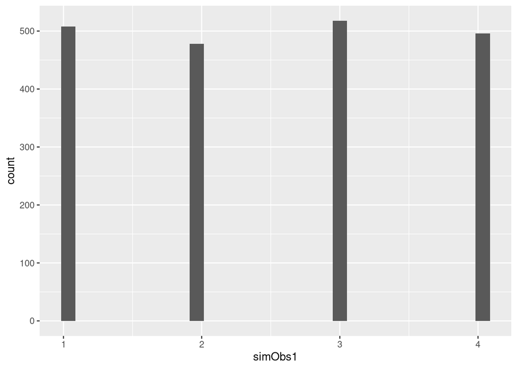

```r
## PLOT
as.data.frame(simObs1)%>%
  ggplot()+
  geom_histogram(aes(x=simObs1))
```

#### Inclusion Probability Definition

Since each sample has a known probability of selection, we can calculate the probability of each unit being included in a sample. This probability is known as the **inclusion probability** , $\pi_i$, which is the sum of the probabilities of all possible samples that contain unit $i$.

It can be shown through combinatorics that the inclusion probability in this simple random random is $\pi_i=1/2$ for all $i$.